# Using K-Means Clustering in Soccer: An Applied Case Study

- Show All Code
- Hide All Code
- View Source

Author

Theofanis Tsitroulis

[figure not shown]

# Introduction and Dataset

Individualized training is especially important in amateur soccer, where physical differences within squads are often large. This case study applies K-Means clustering to identify performance profiles using simple field tests.

Data were collected in early pre-season and included countermovement jump, squat jump, 20 m sprint, and Illinois agility tests. Jump performance was measured using an accelerometer, whereas single-beam timing gates were used for the 20 m sprint and Illinois agility tests.

## Libraries

```python
import pandas as pd
import seaborn as sns
import matplotlib.pyplot as plt
from sklearn.cluster import KMeans
from sklearn.preprocessing import StandardScaler
```

## Load the dataset

```python
df_raw = pd.read_csv("C:/Users/user/Desktop/R files/aver.csv")

df_raw.head(2)
```

```
    NAME   SJ1   SJ2   SJ3  sjmax  ...  SPRINT2  sprint  AGILITY1  AGILITY2    agi
0  LUCAS  32.9  35.8  32.9   35.8  ...     3.03    3.03     15.26     15.58  15.26
1  MATEO  31.7  30.1  31.2   31.7  ...     3.15    3.15     15.75     15.89  15.75

[2 rows x 18 columns]
```

## Select relevant columns

```python
df= df_raw[["cmjmax", "sjmax", "sprint", "agi"]]
df.head()
```

```
   cmjmax  sjmax  sprint    agi
0   42.40   35.8    3.03  15.26
1   34.50   31.7    3.15  15.75
2   28.20   24.3    3.37  16.56
3   44.23   35.7    3.25  18.50
4   34.70   26.2    3.36  16.25
```

## Rename the columns

```python
df = df.rename({"cmjmax" : "Countermovement Jump",
"sjmax" : "Squat Jump",
"sprint": "20m Sprint",
"agi": "Illinois Agility Test"}, axis = 1)

df.head(2)
```

```
   Countermovement Jump  Squat Jump  20m Sprint  Illinois Agility Test
0                  42.4        35.8        3.03                  15.26
1                  34.5        31.7        3.15                  15.75
```

## Exploratory Data Analysis

#### A basic descriptive analysis highlights substantial variability across all physical tests. This variation reflects one of the core challenges in amateur coaching: managing a squad with highly diverse physical profiles. Even before clustering, it’s evident that a one-size-fits-all training approach is unlikely to be effective.

```python
df.describe().round(2)
```

```
       Countermovement Jump  Squat Jump  20m Sprint  Illinois Agility Test
count                 27.00       27.00       27.00                  27.00
mean                  36.85       31.72        3.23                  16.34
std                    4.63        3.59        0.17                   0.81
min                   28.20       24.30        2.96                  15.14
25%                   34.00       29.00        3.09                  15.83
50%                   36.20       31.20        3.20                  16.14
75%                   39.50       34.90        3.36                  16.72
max                   46.73       37.50        3.62                  18.50
```

## Data Visualization

#### Visual summaries highlight the wide range of physical abilities, reinforcing the need for individualized training—especially in amateur teams

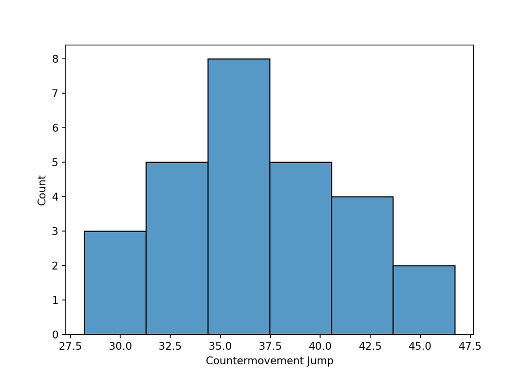

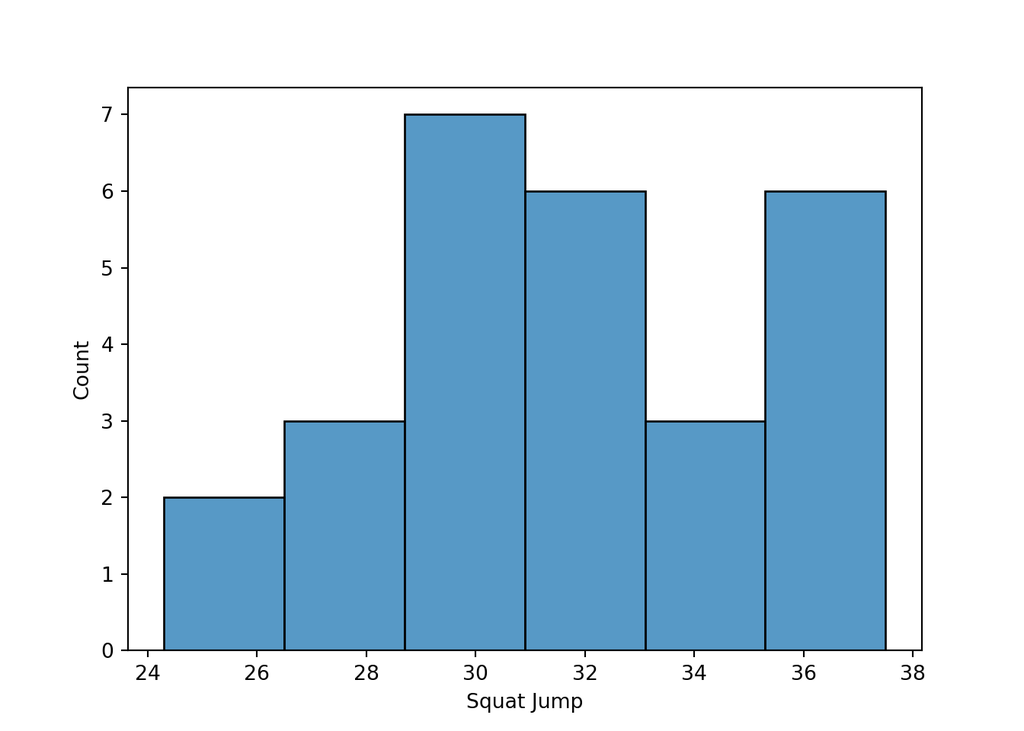

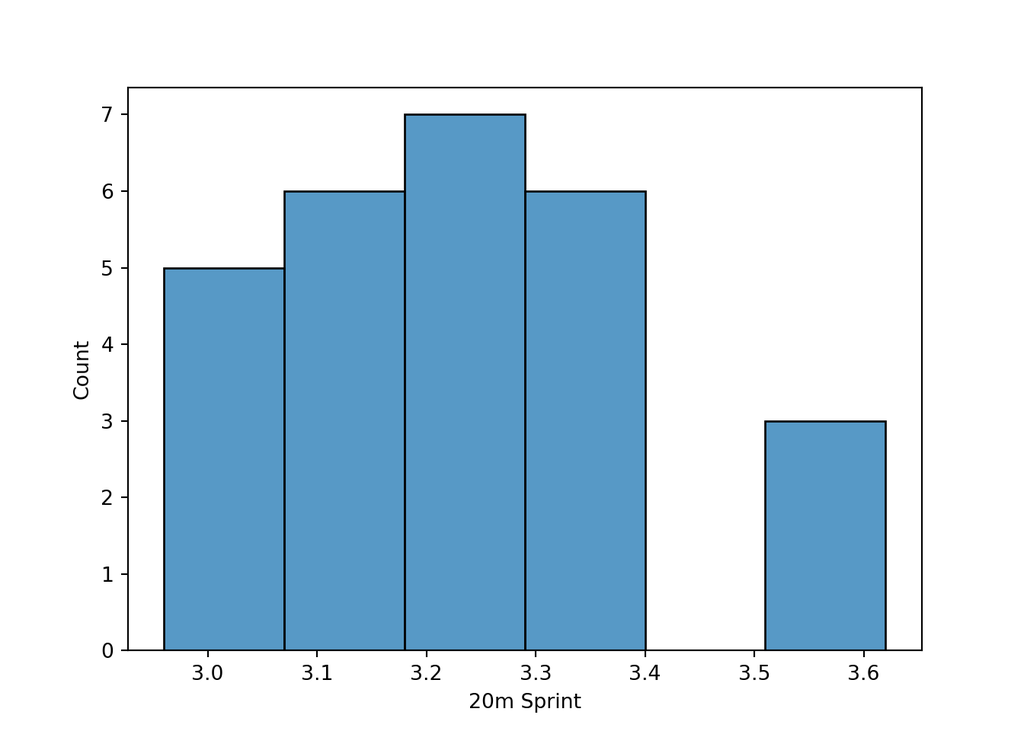

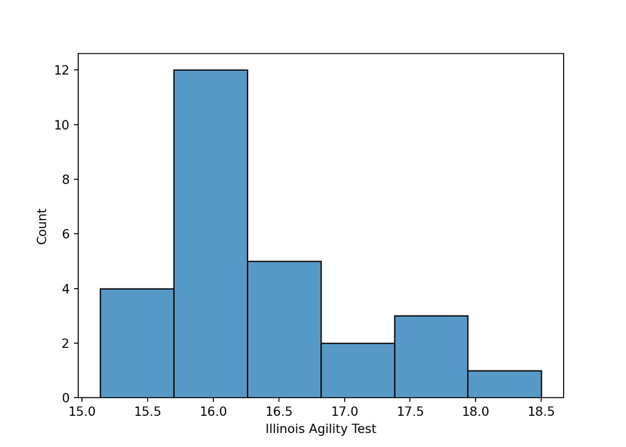

```python
for col in df.select_dtypes("number").columns:
  sns.histplot(data = df, x = col)
  plt.show()
```

# Modelling the Data

#### Standardizing the data ensures that no single test dominates the clustering process due to differences in units or magnitude

```python
std = StandardScaler()

df_std = pd.DataFrame(
    std.fit_transform(df),
    columns=df.columns
)

df_std.head()
```

```
   Countermovement Jump  Squat Jump  20m Sprint  Illinois Agility Test
0              1.221166    1.158854   -1.182762              -1.362502
1             -0.518347   -0.005258   -0.469140              -0.744965
2             -1.905554   -2.106338    0.839166               0.275861
3              1.624117    1.130461    0.125545               2.720803
4             -0.474309   -1.566871    0.779698              -0.114825
```

## Inverting Time-Based Metrics

#### Sprint and agility times were inverted so that better (faster) results align with higher scores

```python
df_std = df_std.assign(
    **{
        "20m Sprint": df_std["20m Sprint"] * -1,
        "Illinois Agility Test": df_std["Illinois Agility Test"] * -1
    }
)
```

# The KMeans Algorithm

#### K-Means clustering was used to group players based on similar performance characteristics. The final model was selected using standard clustering diagnostics and visual inspection.

## Inertia Plot (Elbow Method) - Practical Explanation

#### The inertia plot helps select a reasonable number of clusters by showing when additional groups add little practical value.

### Step 1 - Build a for loop

#### A loop runs K-Means across different values of *k* and stores the inertia for each model.

```python
inertia_values = []

for k in range(2, 10):
    kmeans = KMeans(n_clusters = k, n_init = 'auto', random_state = 42)
    kmeans.fit(df_std)
    inertia_values.append(kmeans.inertia_)
```

```
KMeans(n_clusters=9, random_state=42)
```

### Step 2 – Store Inertia Values

#### The inertia values are stored in a Pandas Series to make them easier to inspect and plot.

```python
inertia_series = pd.Series(inertia_values, index = range(2, 10))
inertia_series
```

```
2    70.364384
3    47.648285
4    31.411059
5    22.965369
6    19.337348
7    16.920764
8    14.889999
9    11.580219
dtype: float64
```

### Step 3 – Visualize the Elbow

#### The inertia values are plotted across *k* to help identify the elbow point.

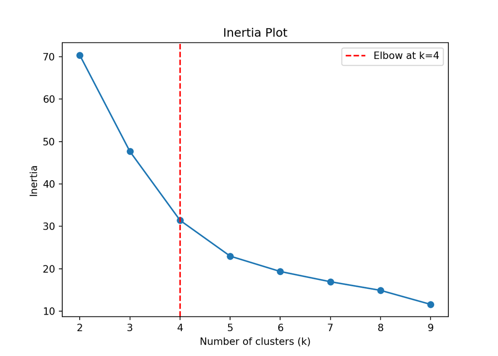

```python
inertia_series.plot(marker = 'o')
plt.axvline(x=4, color='r', linestyle='--', label='Elbow at k=4')

plt.title('Inertia Plot')
plt.xlabel('Number of clusters (k)')
plt.ylabel('Inertia')
plt.legend()
plt.show()
```

## Step 4 – Apply KMeans (k=4)

#### KMeans was applied using 4 clusters as a starting point to explore how athletes might naturally group based on their test results.

```python
kmeans4 = KMeans(n_clusters = 4, n_init = "auto", random_state = 42)
kmeans4.fit(df_std)
```

```
KMeans(n_clusters=4, random_state=42)
```

## Step 5 – Cluster Sizes

#### After fitting the KMeans model, each player was assigned to one of the four clusters. The distribution of players was as follows:

Cluster 3: 11 Players

Cluster 1: 9 Players

Cluster 0: 5 Players

Cluster 2: 2 Players

```python
from collections import Counter

Counter(kmeans4.labels_)
```

```
Counter({np.int32(3): 11, np.int32(1): 9, np.int32(0): 5, np.int32(2): 2})
```

## Step 6 – Understanding Group Profiles

#### Cluster centers represent the average performance profile of each group across all tests. They provide a simple way to understand what defines each cluster and how athletes differ from one another.

```python
kmeans4.cluster_centers_
```

```
array([[ 1.45148669,  1.25539002,  1.01625026,  1.06003489],
       [-0.99298255, -1.01478587, -0.99774895, -0.49150891],
       [ 1.20245   ,  1.28662229, -0.39315273, -2.07175907],
       [-0.06595368,  0.02571619,  0.42589043,  0.29699308]])
```

### Step 7 – Visualizing Cluster Centers

#### A heatmap was used to visualize the cluster centers across all tests. Values are standardized: **red indicates below-average performance**, and **blue indicates above-average**. This allows for quick interpretation of each group’s strengths and weaknesses.

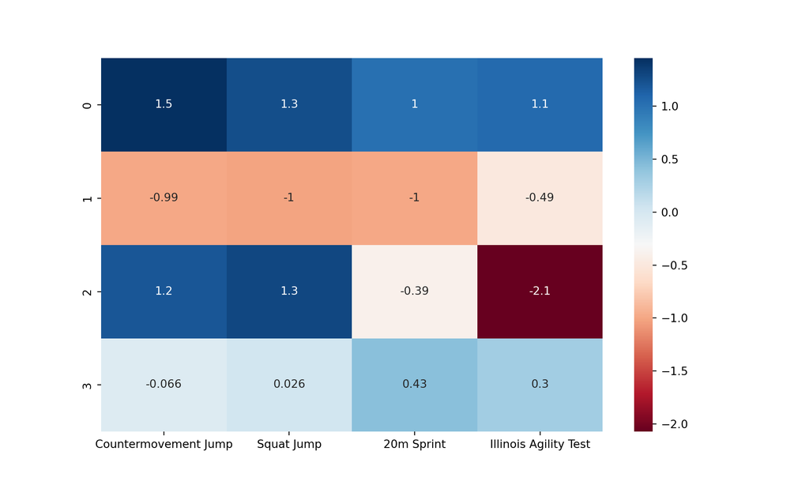

```python
plt.figure(figsize = (10, 6))

sns.heatmap(pd.DataFrame(kmeans4.cluster_centers_, columns = df_std.columns), annot=True, cmap="RdBu")
```

## Clusters Interpretation

### Cluster 0 – High Overall Athleticism

#### Above-average performance in all areas: jump, sprint, and agility.

*Coaching focus:* Maintain current qualities through balanced training.

### Cluster 1 – Low Overall Athleticism

#### Below-average scores across all tests.

*Coaching focus:* Emphasize general physical development and build foundational strength.

### Cluster 2 – Power-Dominant, Speed-Limited

#### Strong jump performance, but limited sprint and agility capacity.

*Coaching focus:* Improve sprint mechanics, horizontal force production, and overall movement efficiency.

### Cluster 3 – Speed-Oriented, Lower Power

#### Above-average sprint and agility results with moderate jumping ability.

*Coaching focus:* Develop power and explosiveness without sacrificing speed.

## The Silhouette Score

The silhouette score was used to assess cluster separation. While higher values indicate clearer separation, some overlap is expected in applied sports performance data.

```python
from sklearn.metrics import silhouette_score

labels = kmeans4.fit_predict(df_std)
score = silhouette_score(df_std, labels)

print(f"Silhouette score for k=4: {score:.3f}")
```

```
Silhouette score for k=4: 0.346
```

# Rationale for Exploring a Three-Cluster Solution

#### A three-cluster solution was explored to determine whether a simpler grouping could capture the main structure of the data. Fewer clusters can improve interpretability and practical use without meaningful loss of information.

### KMeans Model with 3 Clusters

```python
kmeans3 = KMeans(n_clusters = 3, n_init = "auto", random_state = 42)
kmeans3.fit(df_std)
```

```
KMeans(n_clusters=3, random_state=42)
```

### Cluster Sizes

#### The number of players in each cluster was checked to see how evenly the groups were distributed.

Cluster 1: 16 Players

Cluster 2: 3 Players

Cluster 0: 8 Players

```python
Counter(kmeans3.labels_)
```

```
Counter({np.int32(1): 16, np.int32(0): 8, np.int32(2): 3})
```

### The Cluster Centers

#### The cluster centers represent the average standardized performance for each group in the three-cluster model.

```python
kmeans3.cluster_centers_
```

```
array([[ 1.02932435,  1.00269256,  0.78134976,  0.79695159],
       [-0.64770989, -0.68136561, -0.22218085, -0.0198669 ],
       [ 0.70958781,  0.9601031 , -0.89863482, -2.01924743]])
```

### Visualize the data

#### As before, red indicates below-average performance and blue indicates above-average, based on standardized values.

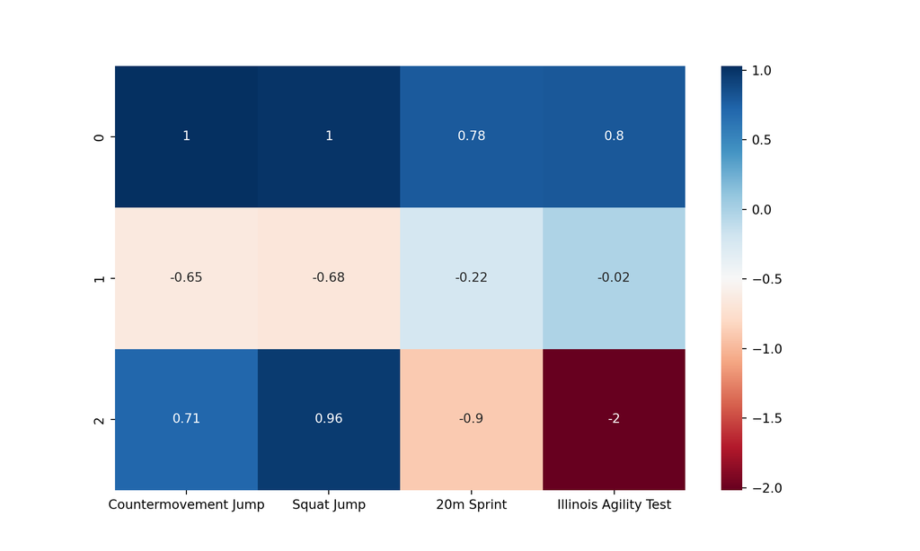

```python
plt.figure(figsize = (10, 6))

sns.heatmap(pd.DataFrame(kmeans3.cluster_centers_, columns = df_std.columns), annot=True, cmap="RdBu")
```

## Three-Cluster Solution (k = 3)

### Cluster 0 – High Overall Athleticism

Above-average performance across jump, sprint, and agility tests.  
**Coaching focus:** Maintain physical qualities, manage load, and support continued development.

### Cluster 1 – Lower Power, Average Speed and Agility

Below-average countermovement and squat jump performance, with sprint and agility values close to the squad average.  
**Coaching focus:** Improve force production and general strength.

### Cluster 2 – Power-Dominant, Speed- and Agility-Limited

Above-average jump performance combined with clearly lower sprint and agility outcomes.  
**Coaching focus:** Improve sprint mechanics, horizontal force production, and transfer of strength to on-field movement.

## Player Group Assignments

Each player was assigned to a cluster from the final model, enabling practical use in planning and monitoring.

```python
df_model = pd.concat([df_raw.NAME, df_std, pd.Series(kmeans3.labels_, name="Cluster")], axis = 1)
df_model.head()
```

```
     NAME  Countermovement Jump  ...  Illinois Agility Test  Cluster
0   LUCAS              1.221166  ...               1.362502        0
1   MATEO             -0.518347  ...               0.744965        1
2    PAUL             -1.905554  ...              -0.275861        1
3  THOMAS              1.624117  ...              -2.720803        2
4    NICK             -0.474309  ...               0.114825        1

[5 rows x 6 columns]
```

### Final Concatenation

#### Descriptive labels were added to each player based on their cluster assignment. This makes the results easier to read and apply in practice.

```python
cluster_labels = {
    0: "High Overall Athleticism",
    1: "Lower Power, Avg Speed/Agility",
    2: "Power-Dominant, Speed-Limited"
}

# Map the numeric cluster to the descriptive label
df_model["Cluster Label"] = df_model["Cluster"].map(cluster_labels)

# Preview the result
df_model.head()
```

```
     NAME  Countermovement Jump  ...  Cluster                   Cluster Label
0   LUCAS              1.221166  ...        0        High Overall Athleticism
1   MATEO             -0.518347  ...        1  Lower Power, Avg Speed/Agility
2    PAUL             -1.905554  ...        1  Lower Power, Avg Speed/Agility
3  THOMAS              1.624117  ...        2   Power-Dominant, Speed-Limited
4    NICK             -0.474309  ...        1  Lower Power, Avg Speed/Agility

[5 rows x 7 columns]
```

## Cluster 0 - High Overall Athleticism

#### View players assigned to Cluster 0

```python
df_model.loc[df_model["Cluster"] == 0]
```

```
       NAME  Countermovement Jump  ...  Cluster             Cluster Label
0     LUCAS              1.221166  ...        0  High Overall Athleticism
10    JASON              1.353281  ...        0  High Overall Athleticism
15      SAM              0.362419  ...        0  High Overall Athleticism
16  MICHAEL              1.045013  ...        0  High Overall Athleticism
17   ROBERT              0.252323  ...        0  High Overall Athleticism
18  WILLIAM              0.362419  ...        0  High Overall Athleticism
24     NOAH              2.174596  ...        0  High Overall Athleticism
26    HENRY              1.463377  ...        0  High Overall Athleticism

[8 rows x 7 columns]
```

## Cluster 1 - Lower Power, Average Speed and Agility

#### View players assigned to Cluster 1

```python
df_model.loc[df_model["Cluster"] == 1]
```

```
           NAME  Countermovement Jump  ...  Cluster                   Cluster Label
1         MATEO             -0.518347  ...        1  Lower Power, Avg Speed/Agility
2          PAUL             -1.905554  ...        1  Lower Power, Avg Speed/Agility
4          NICK             -0.474309  ...        1  Lower Power, Avg Speed/Agility
5         KENNY              0.010113  ...        1  Lower Power, Avg Speed/Agility
7         JAMES             -1.355075  ...        1  Lower Power, Avg Speed/Agility
8          ADAM             -0.540366  ...        1  Lower Power, Avg Speed/Agility
9          BILL             -0.870654  ...        1  Lower Power, Avg Speed/Agility
11      STEWART             -1.333056  ...        1  Lower Power, Avg Speed/Agility
12        LARRY             -0.870654  ...        1  Lower Power, Avg Speed/Agility
13     JONATHAN             -0.628443  ...        1  Lower Power, Avg Speed/Agility
14         GARY             -0.628443  ...        1  Lower Power, Avg Speed/Agility
19      RICHARD             -0.144022  ...        1  Lower Power, Avg Speed/Agility
20      JOSHEPH             -0.254117  ...        1  Lower Power, Avg Speed/Agility
21  CHRISTOPHER             -0.011907  ...        1  Lower Power, Avg Speed/Agility
23         LIAM              0.384438  ...        1  Lower Power, Avg Speed/Agility
25       OLIVER             -1.222960  ...        1  Lower Power, Avg Speed/Agility

[16 rows x 7 columns]
```

## Cluster 2 - Power-Dominant, Speed- and Agility-Limited

#### View players assigned to Cluster 2

```python
df_model.loc[df_model["Cluster"] == 2]
```

```
      NAME  Countermovement Jump  ...  Cluster                  Cluster Label
3   THOMAS              1.624117  ...        2  Power-Dominant, Speed-Limited
6      BEN              0.780783  ...        2  Power-Dominant, Speed-Limited
22     DAN             -0.276137  ...        2  Power-Dominant, Speed-Limited

[3 rows x 7 columns]
```

## Clusters Visualization

#### PCA is used to project the four standardized physical tests into two dimensions, allowing visualization of player distribution across the three clusters.

```python
from sklearn.decomposition import PCA
import plotly.express as px

features = [
    "Countermovement Jump",
    "Squat Jump",
    "20m Sprint",
    "Illinois Agility Test"
]

# PCA for visualization only
pca = PCA(n_components=2)
pca_scores = pca.fit_transform(df_model[features])

df_pca = df_model.copy()
df_pca["PC1"] = pca_scores[:, 0]
df_pca["PC2"] = pca_scores[:, 1]

# Explained variance
explained_var = pca.explained_variance_ratio_.sum() * 100

# Plot
fig = px.scatter(
    df_pca,
    x="PC1",
    y="PC2",
    color="Cluster Label",
    hover_name="NAME",
    title=f"PCA Projection of Player Profiles (PC1–PC2 explain {explained_var:.1f}% variance)"
)

fig.update_layout(
    template="simple_white",
    legend_title_text="Cluster"
)
```

[interactive chart not shown]

# Conclusion & Limitations

This project showed how simple field tests and K-Means clustering can identify clear performance profiles and support individualized training decisions.

The analysis was based on basic field tests only. While accessible and practical, more advanced tools could provide deeper insight into neuromuscular qualities.

Clustering highlights patterns in data but does not replace coaching judgment. Its value depends on informed interpretation and practical context.